# Online Shoppers purchase Intention analysis

JUNO CHONG

For The main purpose of Online Shoppers purchase Intention analysis is to help company predicting the behavior of online shoppers in real time, and use the prediction to achieve company goals like increasing firm. I am going to define the customer as 3 types. target customer/New customer/not interested customer.

First,I use visitortype = 1 , Revenue =“TRUE” ,mean he/she is a new visitor and he/she purchase our prodcut. he/she a target customer. Also,visitortype = 0 means , Revenue= “TRUE” mean he/she is our target customer too. Second, I use visitortype = 0,Revenue = “FALSE” as not interested customers. Third , I use visitortype = 1,Revenue = “FALSE” as a New customer. last, if the visitortype is -1, which is undefined, I use subset function to clear the row with undefined vistortype, to increase accuracy of my report.

```r
library(ggplot2)
library(psych)
library(corrplot)
library(VIM)
library(gridExtra)
library(car)
library(knitr)
library(gmodels)
library(EMCluster)
library(clValid)
library(dplyr)
setwd("C:/b452f")
dat <- read.csv("online_shoppers.csv",header=TRUE) %>%
  mutate(Month=NULL,OperatingSystems=NULL,Browser=NULL,Region=NULL,TrafficType=NULL,Weekend=NULL)




for(i in 1:nrow(dat)){
  if(dat$VisitorType[i] == 1 & dat$Revenue[i] == "FALSE"){dat$customertype[i] <- "new_customer"}else if(dat$VisitorType[i] == 1 & dat$Revenue[i] =="TRUE"){dat$customertype[i] <- "target_customer"}
  else if(dat$VisitorType[i] == 0 & dat$Revenue[i] =="FALSE" ){dat$customertype[i] <-"not_interseted_customer"}else if(dat$VisitorType[i] == 0 & dat$Revenue[i] =="TRUE"){dat$customertype[i] <- "target_customer"} else{dat$customertype[i] <- "NULL"}}

dat1<-subset(dat, customertype!="NULL" )

summary(dat1)
```

```
##  Administrative   Administrative_Duration Informational
##  Min.   : 0.000   Min.   :   0.00         Min.   : 0.0000
##  1st Qu.: 0.000   1st Qu.:   0.00         1st Qu.: 0.0000
##  Median : 1.000   Median :   8.00         Median : 0.0000
##  Mean   : 2.321   Mean   :  80.94         Mean   : 0.5058
##  3rd Qu.: 4.000   3rd Qu.:  93.60         3rd Qu.: 0.0000
##  Max.   :27.000   Max.   :3398.75         Max.   :24.0000
##  Informational_Duration ProductRelated   ProductRelated_Duration
##  Min.   :   0.00        Min.   :  0.00   Min.   :    0.0
##  1st Qu.:   0.00        1st Qu.:  7.00   1st Qu.:  186.2
##  Median :   0.00        Median : 18.00   Median :  602.6
##  Mean   :  34.63        Mean   : 31.87   Mean   : 1199.1
##  3rd Qu.:   0.00        3rd Qu.: 38.00   3rd Qu.: 1472.0
##  Max.   :2549.38        Max.   :705.00   Max.   :63973.5
##   BounceRates         ExitRates         PageValues        SpecialDay
##  Min.   :0.000000   Min.   :0.00000   Min.   :  0.000   Min.   :0.00000
##  1st Qu.:0.000000   1st Qu.:0.01429   1st Qu.:  0.000   1st Qu.:0.00000
##  Median :0.003175   Median :0.02514   Median :  0.000   Median :0.00000
##  Mean   :0.022078   Mean   :0.04293   Mean   :  5.804   Mean   :0.06185
##  3rd Qu.:0.016923   3rd Qu.:0.05000   3rd Qu.:  0.000   3rd Qu.:0.00000
##  Max.   :0.200000   Max.   :0.20000   Max.   :361.764   Max.   :1.00000
##   Revenue         VisitorType     customertype
##  Mode :logical   Min.   :0.0000   Length:12245
##  FALSE:10353     1st Qu.:0.0000   Class :character
##  TRUE :1892      Median :0.0000   Mode  :character
##                  Mean   :0.1383
##                  3rd Qu.:0.0000
##                  Max.   :1.0000
```

```r
customerbehave<-dat1[1:10]

colMeans(customerbehave)
```

```
##          Administrative Administrative_Duration           Informational
##            2.321029e+00            8.094441e+01            5.058391e-01
##  Informational_Duration          ProductRelated ProductRelated_Duration
##            3.463058e+01            3.186517e+01            1.199080e+03
##             BounceRates               ExitRates              PageValues
##            2.207782e-02            4.293205e-02            5.803858e+00
##              SpecialDay
##            6.185382e-02
```

## R Markdown

We are looking to gain better insight between understanding customer behaviour, by dividing it to category it to target customers not interested customers and new customers. Below is a ggplot which is a relationship between different variables, and their customer type.

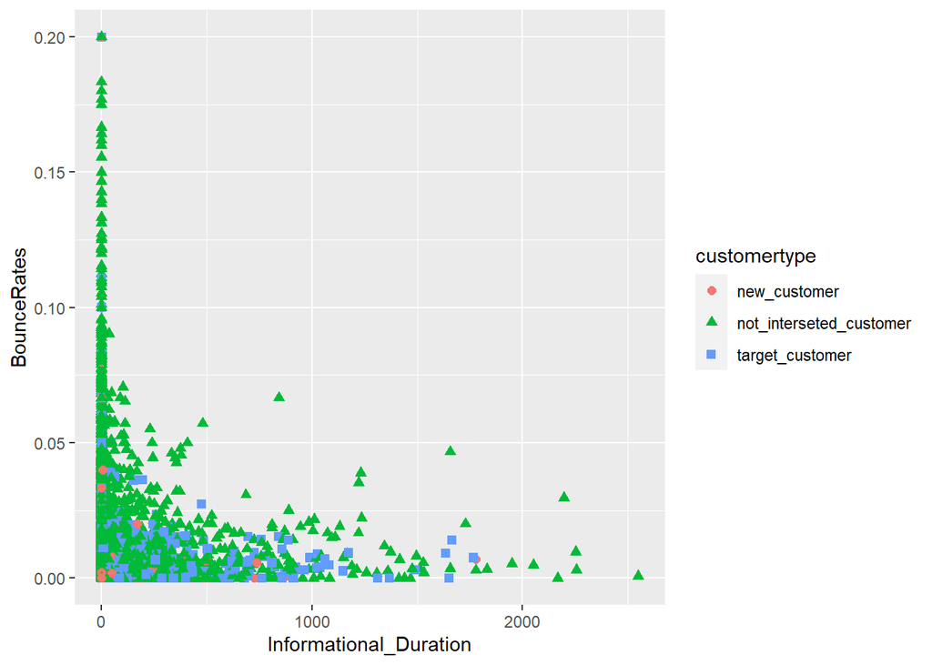

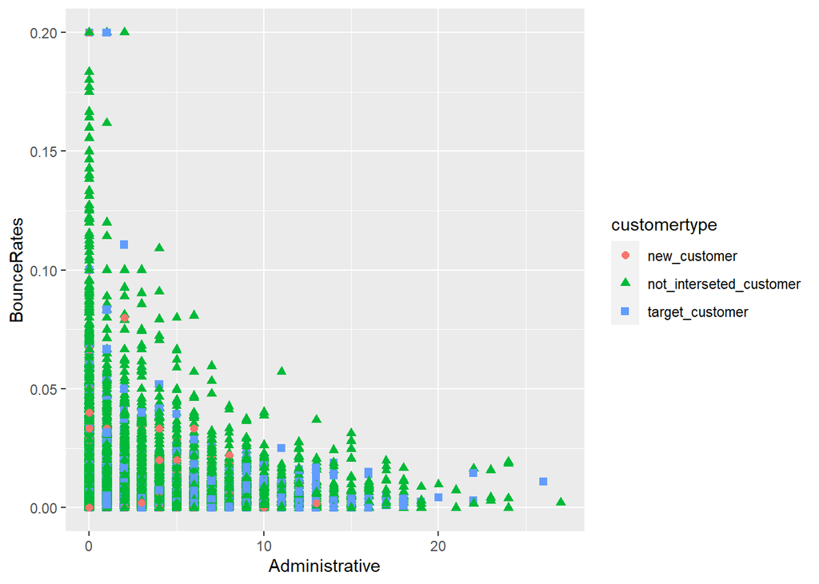

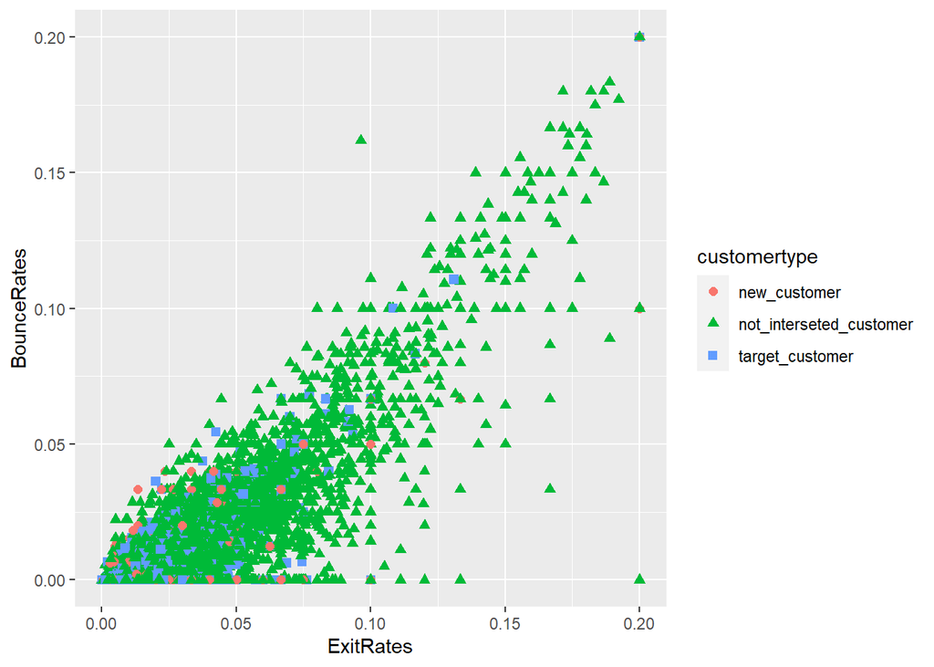

[figure not shown]

[figure not shown]

[figure not shown]

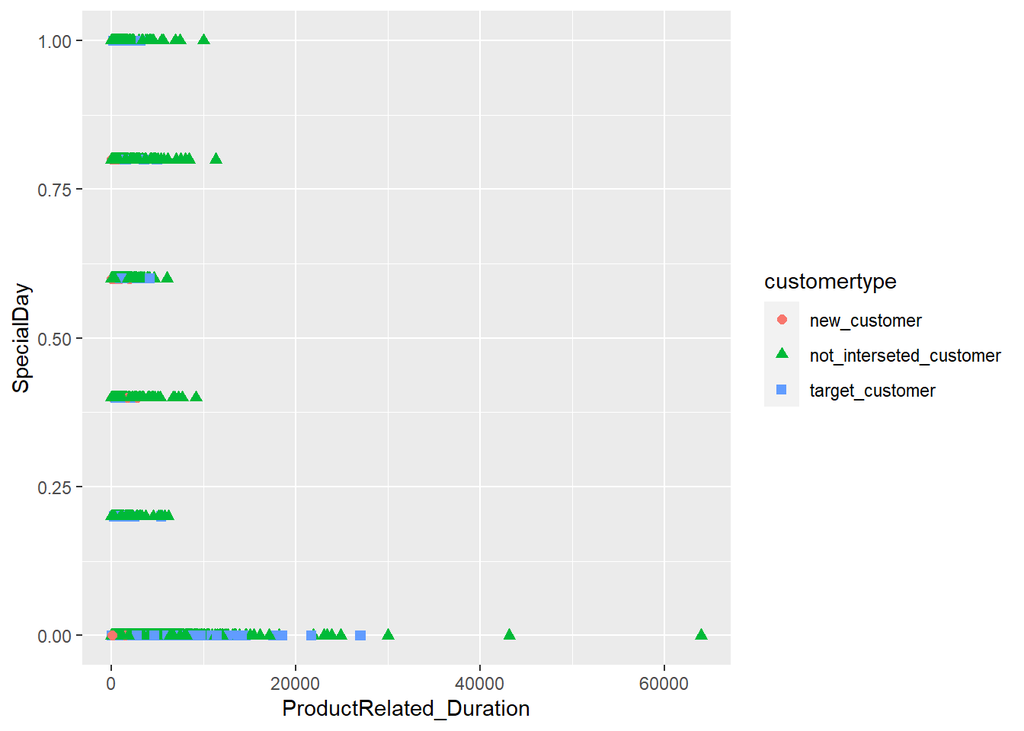

## clusting anylsis

```r
explore<-function(x){
 print(head(x))
 mf<-function(x){c(min=min(x), max=max(x), mean=mean(x), sd=sd(x))}
 round(apply(x, 2, mf),4)
}
customerbehave<-dat1[1:10]

# normalization function
normalize<-function(x) {(x - min(x))/(max(x) - min(x))}
n_customerbehave<-as.data.frame(lapply(customerbehave,normalize))
explore(n_customerbehave)
```

```
##   Administrative Administrative_Duration Informational Informational_Duration
## 1              0                       0             0                      0
## 2              0                       0             0                      0
## 3              0                       0             0                      0
## 4              0                       0             0                      0
## 5              0                       0             0                      0
## 6              0                       0             0                      0
##   ProductRelated ProductRelated_Duration BounceRates ExitRates PageValues
## 1    0.001418440            0.000000e+00  1.00000000  1.000000          0
## 2    0.002836879            1.000414e-03  0.00000000  0.500000          0
## 3    0.001418440            0.000000e+00  1.00000000  1.000000          0
## 4    0.002836879            4.168391e-05  0.25000000  0.700000          0
## 5    0.014184397            9.808746e-03  0.10000000  0.250000          0
## 6    0.026950355            2.410633e-03  0.07894737  0.122807          0
##   SpecialDay
## 1          0
## 2          0
## 3          0
## 4          0
## 5          0
## 6          0
```

```
##      Administrative Administrative_Duration Informational
## min          0.0000                  0.0000        0.0000
## max          1.0000                  1.0000        1.0000
## mean         0.0860                  0.0238        0.0211
## sd           0.1232                  0.0520        0.0530
##      Informational_Duration ProductRelated ProductRelated_Duration BounceRates
## min                  0.0000         0.0000                  0.0000      0.0000
## max                  1.0000         1.0000                  1.0000      1.0000
## mean                 0.0136         0.0452                  0.0187      0.1104
## sd                   0.0554         0.0632                  0.0300      0.2410
##      ExitRates PageValues SpecialDay
## min     0.0000      0.000     0.0000
## max     1.0000      1.000     1.0000
## mean    0.2147      0.016     0.0619
## sd      0.2419      0.050     0.1995
```

```r
#z-score normalization
z_customerbehave<-scale(customerbehave)
explore(z_customerbehave)
```

```
##   Administrative Administrative_Duration Informational Informational_Duration
## 1     -0.6978323              -0.4584025    -0.3973691              -0.245368
## 2     -0.6978323              -0.4584025    -0.3973691              -0.245368
## 3     -0.6978323              -0.4584025    -0.3973691              -0.245368
## 4     -0.6978323              -0.4584025    -0.3973691              -0.245368
## 5     -0.6978323              -0.4584025    -0.3973691              -0.245368
## 6     -0.6978323              -0.4584025    -0.3973691              -0.245368
##   ProductRelated ProductRelated_Duration BounceRates  ExitRates PageValues
## 1     -0.6928507              -0.6255854  3.69123735  3.2466666 -0.3210896
## 2     -0.6704030              -0.5921953 -0.45803427  1.1796207 -0.3210896
## 3     -0.6928507              -0.6255854  3.69123735  3.2466666 -0.3210896
## 4     -0.6704030              -0.6241942  0.57928363  2.0064391 -0.3210896
## 5     -0.4908218              -0.2982054 -0.04310711  0.1460978 -0.3210896
## 6     -0.2887929              -0.5451273 -0.13046019 -0.3797297 -0.3210896
##   SpecialDay
## 1 -0.3099813
## 2 -0.3099813
## 3 -0.3099813
## 4 -0.3099813
## 5 -0.3099813
## 6 -0.3099813
```

```
##      Administrative Administrative_Duration Informational
## min         -0.6978                 -0.4584       -0.3974
## max          7.4199                 18.7893       18.4562
## mean         0.0000                  0.0000        0.0000
## sd           1.0000                  1.0000        1.0000
##      Informational_Duration ProductRelated ProductRelated_Duration BounceRates
## min                 -0.2454        -0.7153                 -0.6256     -0.4580
## max                 17.8177        15.1103                 32.7508      3.6912
## mean                 0.0000         0.0000                  0.0000      0.0000
## sd                   1.0000         1.0000                  1.0000      1.0000
##      ExitRates PageValues SpecialDay
## min    -0.8874    -0.3211    -0.3100
## max     3.2467    19.6929     4.7015
## mean    0.0000     0.0000     0.0000
## sd      1.0000     1.0000     1.0000
```

From the above result, It shown that diiferent numeric variables df and mix,max,mean,sd. We are ready for the K-mean.

```r
library(factoextra)
```

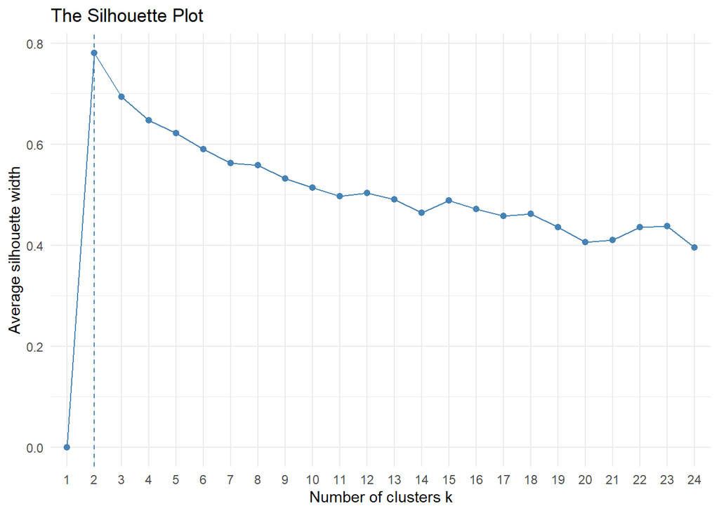

```r
library(NbClust)
fviz_nbclust(customerbehave, kmeans, method = "silhouette", k.max = 24) + theme_minimal() + ggtitle("The Silhouette Plot")
```

If we were to select k based on the average Silhouette plot. k should be 2. But we will go check scree plot to make the final decision of choosing

Using scree plot for getting the raw data by using algorithms learnt from class.

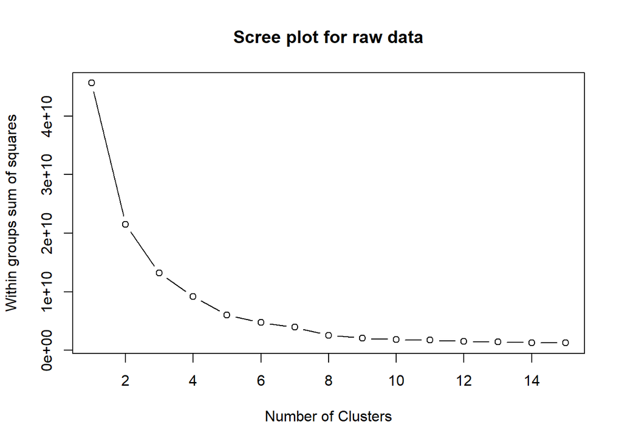

```r
# Scree plot - run k-means multiple times (1 to 15) and plot WCSS against k
wss<-0
for (i in 1:15) {
 wss[i] <- sum(kmeans(customerbehave,centers=i)$withinss)
}
# Plot total within sum of squares vs. number of clusters
plot(1:15, wss, type="b", xlab="Number of Clusters",
 ylab="Within groups sum of squares", main="Scree plot for raw data")
```

Using scree plot for getting the min_max by using algorithm learnt from class.

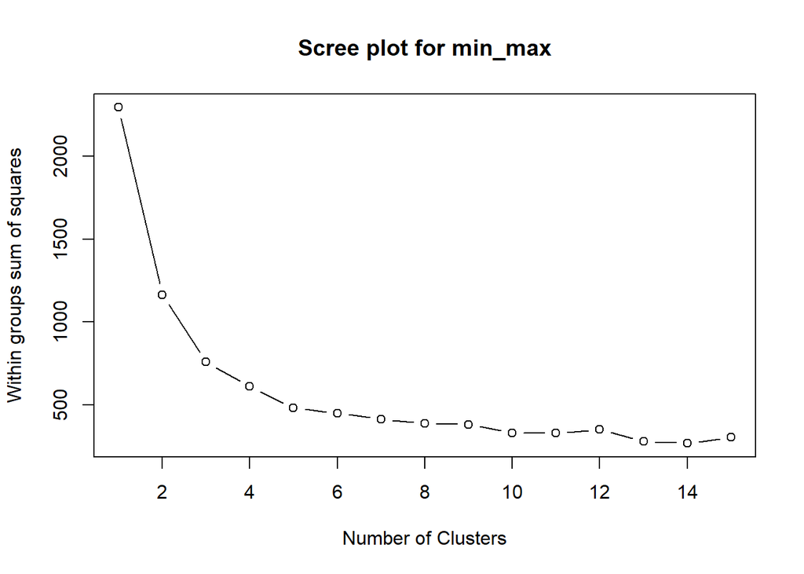

```r
# scree plot for min-max
wss<-0
for (i in 1:15) {
 wss[i] <- sum(kmeans(n_customerbehave,centers=i)$withinss)
}
plot(1:15, wss, type="b", xlab="Number of Clusters",
 ylab="Within groups sum of squares", main="Scree plot for min_max")
```

Using scree plot for getting the z_score by using algorithm learnt from class.

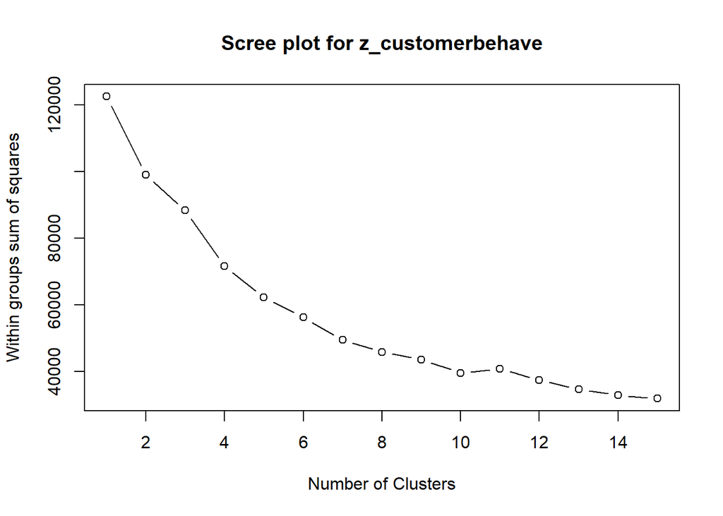

```r
wss<-0
for (i in 1:15) {
 wss[i] <- sum(kmeans(z_customerbehave,centers=i)$withinss)
}
plot(1:15, wss, type="b", xlab="Number of Clusters",
 ylab="Within groups sum of squares", main="Scree plot for z_customerbehave")
```

Cluster the data The cluster below is for the best k value and then compare the clusters against customertype by cross tabulation and scatter plot.

First, we are using Kmeans. From all the plot below, we able to get insight for a during cluster to define customer behaviour as a 3 cluster.

```r
# set seed so that we can reproduce the same cluster
set.seed(1000)
# Set k equal to the number of clusters corresponding to the elbow location
cluster_kmean <- kmeans(customerbehave,3)
cluster_kmean$centers
```

```
##   Administrative Administrative_Duration Informational Informational_Duration
## 1       7.475728               296.79870     2.7427184              266.92191
## 2       1.822209                62.03526     0.3287644               20.04738
## 3       4.330289               154.97350     1.1765601               84.84446
##   ProductRelated ProductRelated_Duration BounceRates  ExitRates PageValues
## 1      236.17476              10892.2713 0.005709582 0.01946272   4.543319
## 2       18.68872                578.6701 0.025336553 0.04757058   5.404909
## 3       77.81786               3355.0877 0.007142700 0.02169103   7.973463
##   SpecialDay
## 1 0.03106796
## 2 0.06464044
## 3 0.05083714
```

```
##
##     new_customer not_interseted_customer target_customer
##   1            1                     135              70
##   2         1213                    7526            1329
##   3           58                    1420             493
```

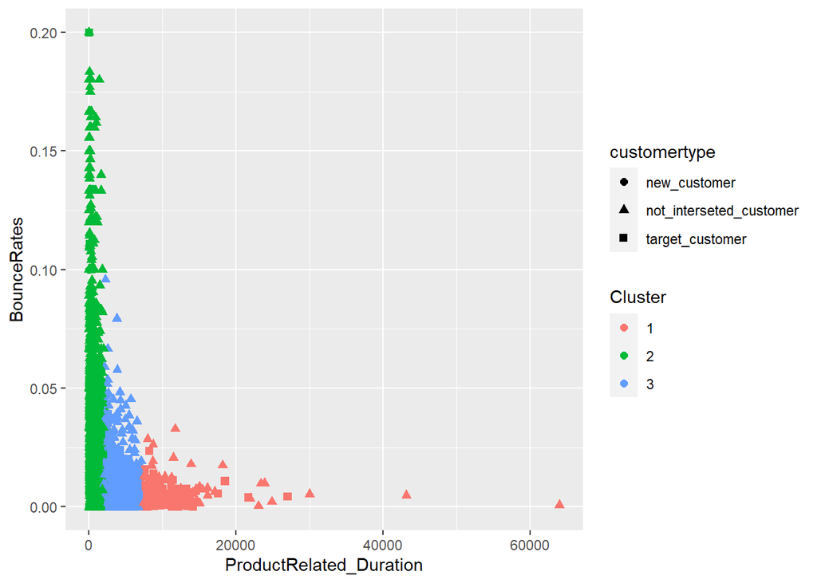

```r
C<- function(dat1,customerbehave,k,c,d,a ,b ){
  set.seed(1000)
  cluster_kmean <-kmeans(customerbehave,k)
print(table(cluster_kmean$cluster,dat1$customertype))
x <- data.frame(cluster_kmean$cluster,dat1$customertype)
ggplot(dat1, aes(c, d,
 shape=customertype,
 colour = as.factor(cluster_kmean$cluster))) +
 geom_point(size=2) +
 labs(colour="Cluster")+labs( x = a , y= b )
}

C(dat1,customerbehave,3,dat1$ProductRelated_Duration,dat1$BounceRates,"ProductRelated_Duration","BounceRates")
```

```r
C(dat1,customerbehave,3,dat1$Informational_Duration,dat1$BounceRates,"Informational_Duration","BounceRates")
```

```
##
##     new_customer not_interseted_customer target_customer
##   1            1                     135              70
##   2         1213                    7526            1329
##   3           58                    1420             493
```

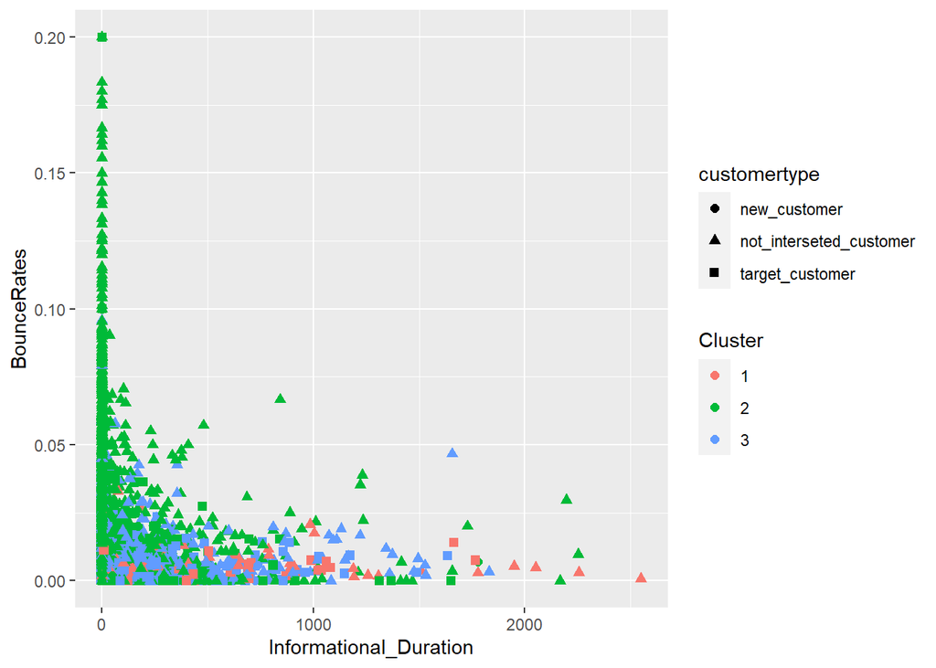

```r
C(dat1,customerbehave,3,dat1$Administrative,dat1$BounceRates,"Administrative","BounceRates")
```

```
##
##     new_customer not_interseted_customer target_customer
##   1            1                     135              70
##   2         1213                    7526            1329
##   3           58                    1420             493
```

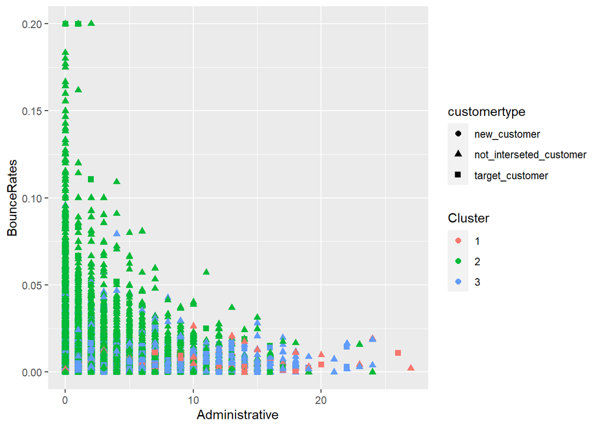

```r
C(dat1,customerbehave,3,dat1$ExitRates,dat1$BounceRates,"ExitRates","BounceRates")
```

```
##
##     new_customer not_interseted_customer target_customer
##   1            1                     135              70
##   2         1213                    7526            1329
##   3           58                    1420             493
```

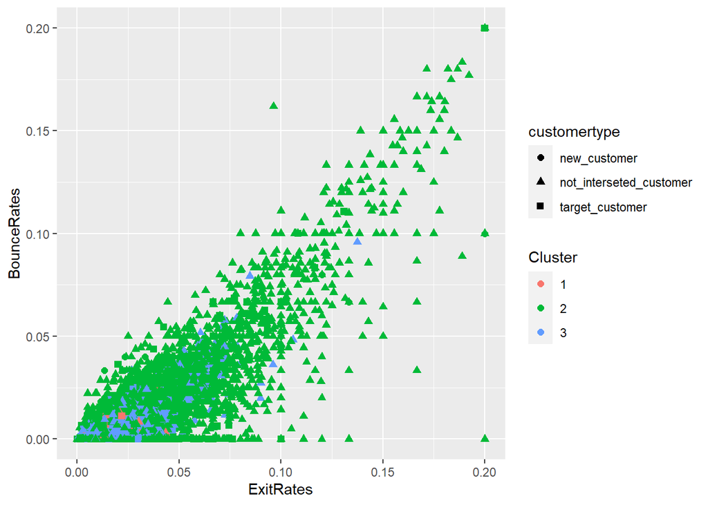

```r
C(dat1,customerbehave,3,dat1$ProductRelated,dat1$BounceRates,"ProductRelated","PageValuess")
```

```
##
##     new_customer not_interseted_customer target_customer
##   1            1                     135              70
##   2         1213                    7526            1329
##   3           58                    1420             493
```

[figure not shown]

```r
C(dat1,customerbehave,3,dat1$Informational,dat1$BounceRates,"Informational","PageValues")
```

```
##
##     new_customer not_interseted_customer target_customer
##   1            1                     135              70
##   2         1213                    7526            1329
##   3           58                    1420             493
```

[figure not shown]

```r
C(dat1,customerbehave,3,dat1$Administrative,dat1$BounceRates,"Administrative","PageValues")
```

```
##
##     new_customer not_interseted_customer target_customer
##   1            1                     135              70
##   2         1213                    7526            1329
##   3           58                    1420             493
```

[figure not shown]

```r
C(dat1,customerbehave,3,dat1$ProductRelated_Duration,dat1$SpecialDay,"ProductRelated_Duration","SpecialDay")
```

```
##
##     new_customer not_interseted_customer target_customer
##   1            1                     135              70
##   2         1213                    7526            1329
##   3           58                    1420             493
```

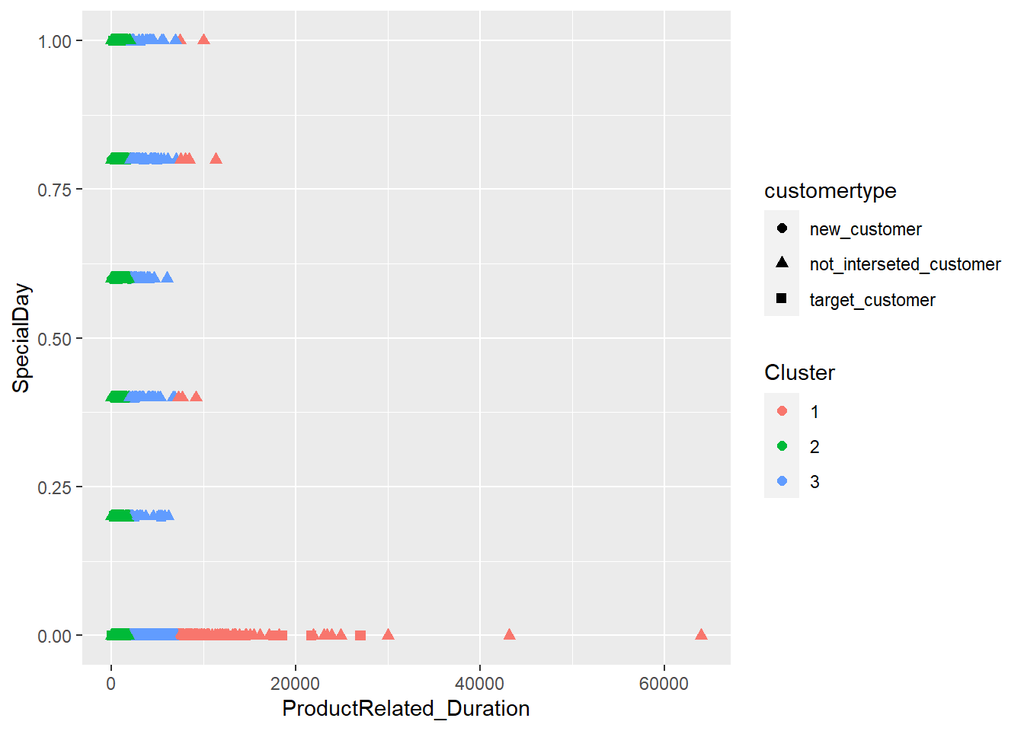

For further investigation on our customer buying intention, we use z-store clusters.

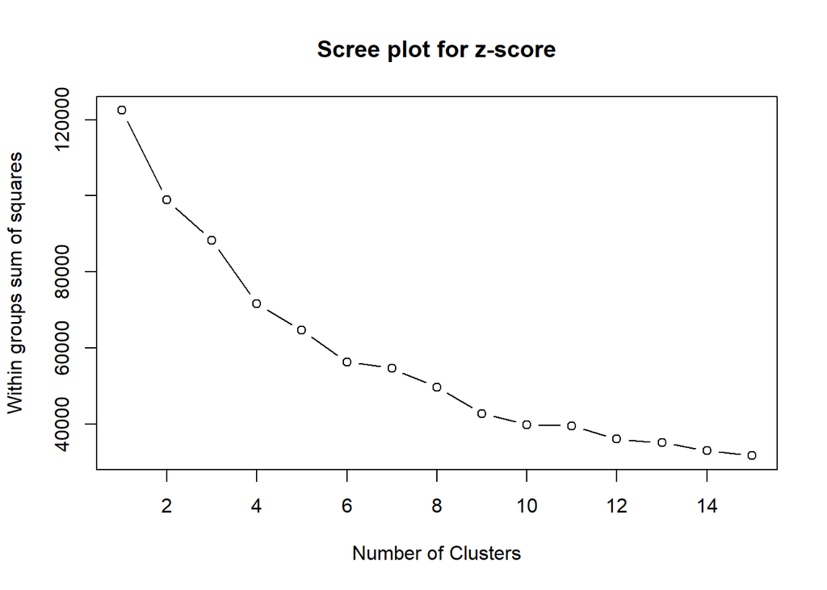

```r
# set seed so that we can reproduce the same cluster
set.seed(1000)
# Set k equal to the number of clusters corresponding to the elbow location
wss<-0
for (i in 1:15) {
 wss[i] <- sum(kmeans(z_customerbehave,centers=i)$withinss)
}
plot(1:15, wss, type="b", xlab="Number of Clusters",
 ylab="Within groups sum of squares", main="Scree plot for z-score")
```

```r
cluster_kmean <- kmeans(z_customerbehave,3)
# Compare the result
table(cluster_kmean$cluster,dat1$customertype)
```

```
##
##     new_customer not_interseted_customer target_customer
##   1           31                     999               6
##   2         1174                    6976            1435
##   3           67                    1106             451
```

```r
C(dat1,z_customerbehave,3,dat1$ProductRelated_Duration,dat1$BounceRates,"ProductRelated_Duration","BounceRates")
```

```
##
##     new_customer not_interseted_customer target_customer
##   1           37                     932              58
##   2           80                    1179             505
##   3         1155                    6970            1329
```

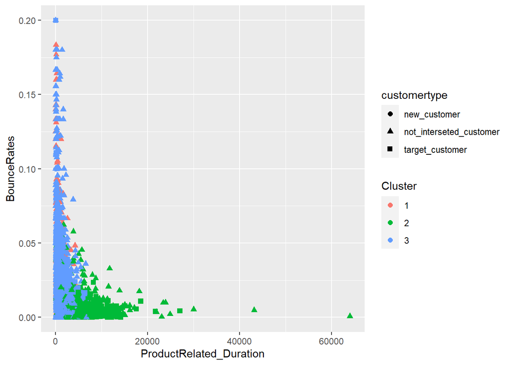

```r
C(dat1,z_customerbehave,3,dat1$Informational_Duration,dat1$BounceRates,"Informational_Duration","BounceRates")
```

```
##
##     new_customer not_interseted_customer target_customer
##   1           37                     932              58
##   2           80                    1179             505
##   3         1155                    6970            1329
```

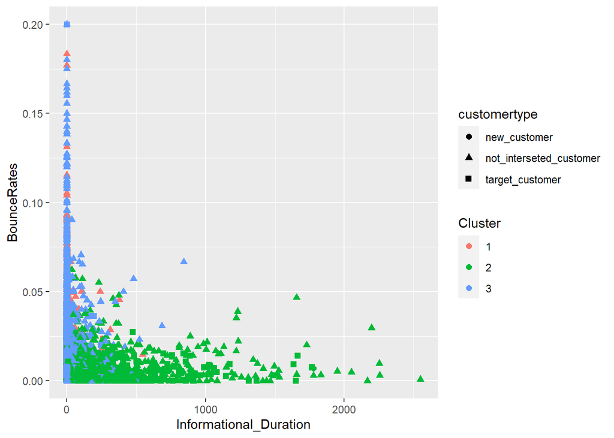

```r
C(dat1,z_customerbehave,3,dat1$Administrative,dat1$BounceRates,"Administrative","BounceRates")
```

```
##
##     new_customer not_interseted_customer target_customer
##   1           37                     932              58
##   2           80                    1179             505
##   3         1155                    6970            1329
```

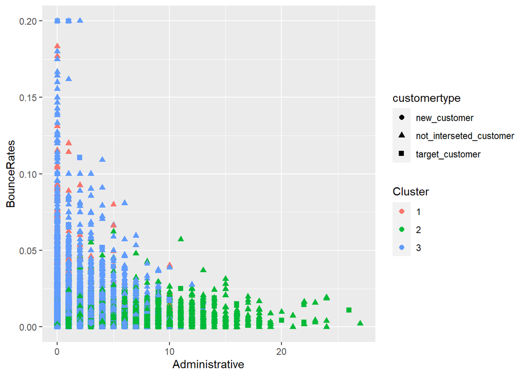

```r
C(dat1,z_customerbehave,3,dat1$ExitRates,dat1$BounceRates,"ExitRates","BounceRates")
```

```
##
##     new_customer not_interseted_customer target_customer
##   1           37                     932              58
##   2           80                    1179             505
##   3         1155                    6970            1329
```

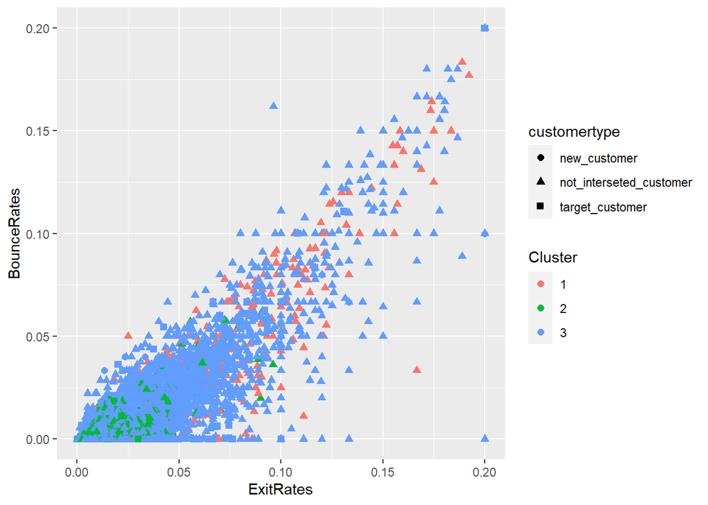

```r
C(dat1,z_customerbehave,3,dat1$ProductRelated,dat1$BounceRates,"ProductRelated","PageValuess")
```

```
##
##     new_customer not_interseted_customer target_customer
##   1           37                     932              58
##   2           80                    1179             505
##   3         1155                    6970            1329
```

[figure not shown]

```r
C(dat1,z_customerbehave,3,dat1$Informational,dat1$BounceRates,"Informational","PageValues")
```

```
##
##     new_customer not_interseted_customer target_customer
##   1           37                     932              58
##   2           80                    1179             505
##   3         1155                    6970            1329
```

[figure not shown]

```r
C(dat1,z_customerbehave,3,dat1$Administrative,dat1$BounceRates,"Administrative","PageValues")
```

```
##
##     new_customer not_interseted_customer target_customer
##   1           37                     932              58
##   2           80                    1179             505
##   3         1155                    6970            1329
```

[figure not shown]

```r
C(dat1,z_customerbehave,3,dat1$ProductRelated_Duration,dat1$SpecialDay,"ProductRelated_Duration","SpecialDay")
```

```
##
##     new_customer not_interseted_customer target_customer
##   1           37                     932              58
##   2           80                    1179             505
##   3         1155                    6970            1329
```

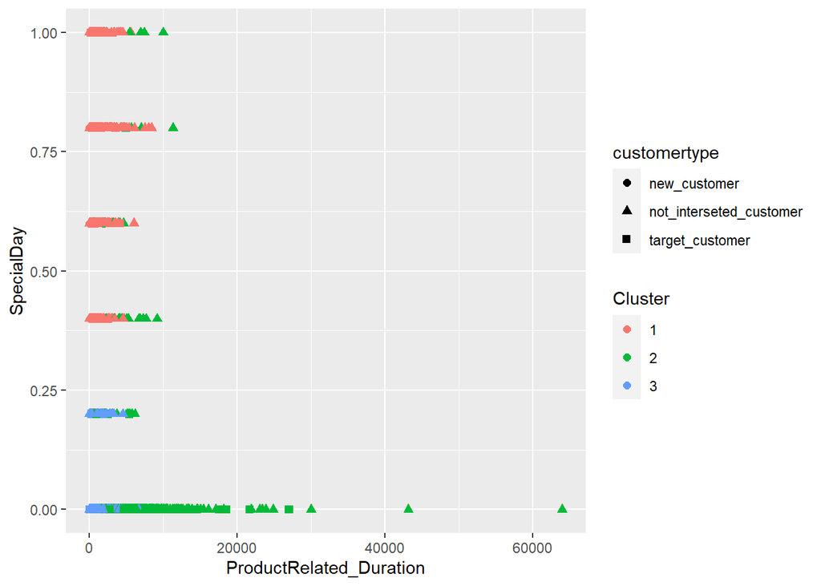

Min_MAX clusters.

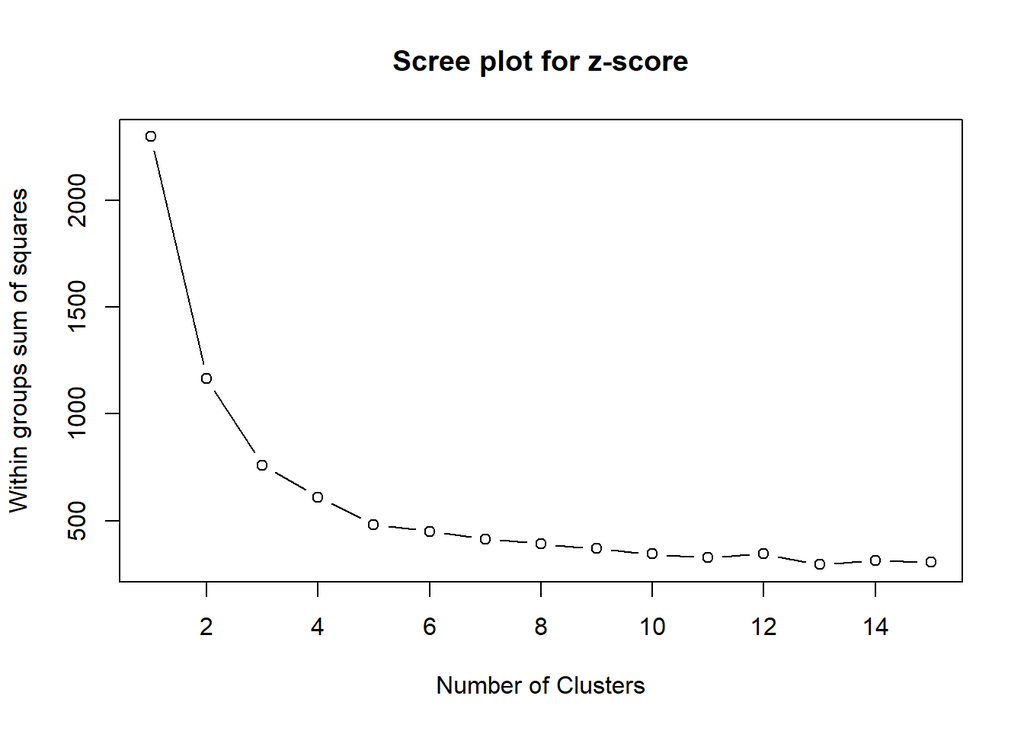

```r
# set seed so that we can reproduce the same cluster
set.seed(1000)
# Set k equal to the number of clusters corresponding to the elbow location
wss<-0
for (i in 1:15) {
 wss[i] <- sum(kmeans(n_customerbehave,centers=i)$withinss)
}
plot(1:15, wss, type="b", xlab="Number of Clusters",
 ylab="Within groups sum of squares", main="Scree plot for z-score")
```

```r
# Set k equal to the number of clusters corresponding to the elbow location
cluster_kmean <- kmeans(n_customerbehave, 3)


C(dat1,n_customerbehave,3,dat1$ProductRelated_Duration,dat1$BounceRates,"ProductRelated_Duration","BounceRates")
```

```
##
##     new_customer not_interseted_customer target_customer
##   1           37                     872              63
##   2         1204                    7288            1823
##   3           31                     921               6
```

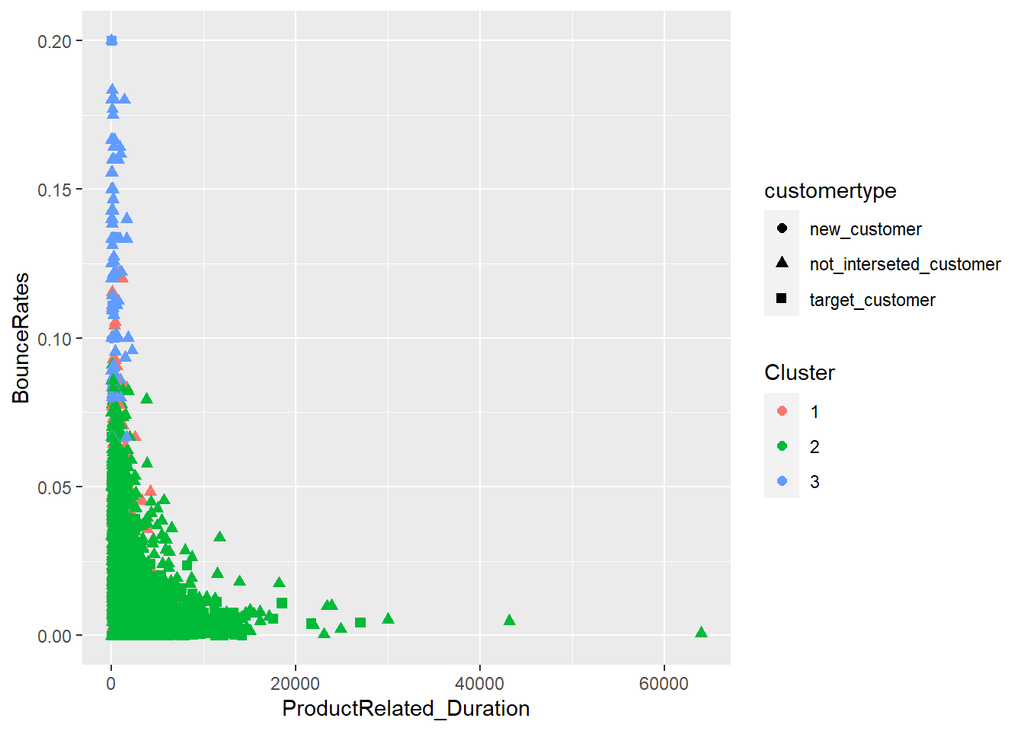

```r
C(dat1,n_customerbehave,3,dat1$Informational_Duration,dat1$BounceRates,"Informational_Duration","BounceRates")
```

```
##
##     new_customer not_interseted_customer target_customer
##   1           37                     872              63
##   2         1204                    7288            1823
##   3           31                     921               6
```

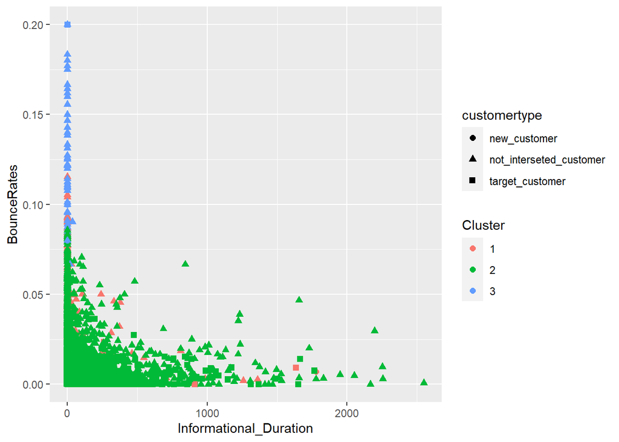

```r
C(dat1,n_customerbehave,3,dat1$Administrative,dat1$BounceRates,"Administrative","BounceRates")
```

```
##
##     new_customer not_interseted_customer target_customer
##   1           37                     872              63
##   2         1204                    7288            1823
##   3           31                     921               6
```

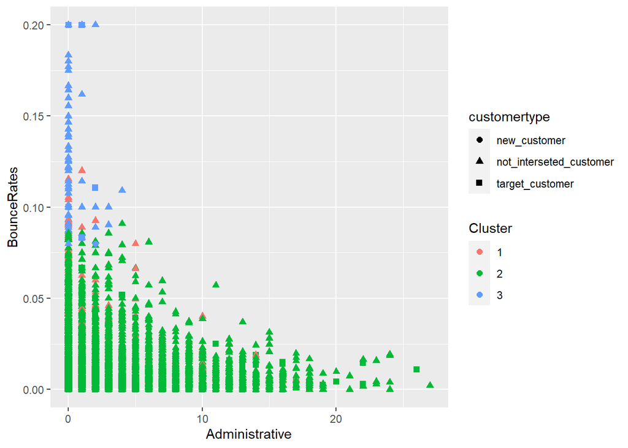